# Map_Analysis

Miyu Niwa

12/1/2021

# Loading Data

Common dataset from Kaggle (https://www.kaggle.com/ruchi798/movies-on-netflix-prime-video-hulu-and-disney)

```r
data<- read.csv("/Users/miyuniwa/Desktop/cleaned_data.csv")
```

# Individual dataframe

Creating individual data frames for each streaming platform

```r
hulu <- data %>%
  filter(Hulu == 1)

netflix <- data %>%
  filter(Netflix == 1)

disney <- data %>%
  filter(`Disney.` == 1)

prime <- data %>%
  filter(`Prime.Video`== 1)
```

# Quick Exploratory Analysis

Basic exploratory analysis on the genres and countries of the data for each streaming platform

# Hulu

- 23 Genres total
- Top Genres:
  - Drama (1328)
  - Thriller (747)
  - Comedy (664)
  - Action (570)
  - Adventure (472)

# Netlfix

- 27 Genres total
- Top Genres:
  - Drama (3596)
  - Comedy (2286)
  - Thriller (1705)
  - Action (1529)
  - Romance

# Disney+

# Amazon Prime

```r
length(unique(data$genres))
```

```
## [1] 27
```

```r
sort(table(data$genres), decreasing=T)
```

```
##
##       Drama      Comedy    Thriller      Action   Adventure     Romance
##        8720        5500        4250        3864        3029        3009
##      Family       Crime     Fantasy Documentary     Mystery      Sci-Fi
##        2399        2323        1816        1707        1459        1429
##      Horror   Animation   Biography     History         War       Music
##        1423        1358        1319        1090         894         639
##       Sport     Musical     Western       Short        News   Film-Noir
##         532         493         390         374          35          34
##  Reality-TV   Talk-Show   Game-Show
##          14          12           3
```

```r
length(unique(hulu$genres))
```

```
## [1] 23
```

```r
length(unique(netflix$genres))
```

```
## [1] 27
```

```r
length(unique(disney$genres))
```

```
## [1] 26
```

```r
length(unique(prime$genres))
```

```
## [1] 27
```

```r
sort(table(hulu$genres), decreasing=T)
```

```
##
##       Drama    Thriller      Comedy      Action   Adventure     Romance
##        1328         747         664         570         472         414
##      Horror       Crime      Sci-Fi     Mystery     Fantasy Documentary
##         345         331         297         270         262         249
##   Biography     History      Family         War   Animation       Music
##         236         230         189         153         138         114
##     Western       Sport     Musical       Short   Film-Noir
##          56          52          31          14           1
```

```r
sort(table(netflix$genres), decreasing=T)
```

```
##
##       Drama      Comedy    Thriller      Action     Romance       Crime
##        3596        2286        1705        1529        1173         985
##   Adventure Documentary      Family     Mystery   Biography     Fantasy
##         931         708         665         640         584         550
##   Animation      Sci-Fi      Horror     History         War       Music
##         470         450         411         404         329         239
##       Sport     Musical       Short     Western        News  Reality-TV
##         209         144         127          64           9           8
##   Talk-Show   Film-Noir   Game-Show
##           7           1           1
```

```r
sort(table(disney$genres), decreasing=T)
```

```
##
##      Family      Comedy   Adventure   Animation     Fantasy       Drama
##        1063         755         743         537         535         405
##      Action     Romance      Sci-Fi     Musical       Short Documentary
##         313         250         243         222         195         162
##       Sport       Music    Thriller       Crime     History   Biography
##          98          70          68          57          51          45
##     Mystery     Western      Horror         War  Reality-TV        News
##          45          20          18           7           5           4
##   Game-Show   Talk-Show
##           2           1
```

```r
sort(table(prime$genres), decreasing=T)
```

```
##
##       Drama      Comedy    Thriller      Action     Romance       Crime
##        3718        1985        1953        1663        1345        1061
##   Adventure      Horror     Mystery Documentary      Family     Fantasy
##        1012         735         623         608         562         557
##   Biography      Sci-Fi     History         War     Western   Animation
##         522         515         486         427         260         250
##       Music       Sport     Musical       Short   Film-Noir        News
##         234         189         122          40          32          22
##   Talk-Show   Game-Show  Reality-TV
##           4           1           1
```

```r
length(unique(hulu$countries))
```

```
## [1] 68
```

```r
length(unique(netflix$countries))
```

```
## [1] 100
```

```r
length(unique(disney$countries))
```

```
## [1] 48
```

```r
length(unique(prime$countries))
```

```
## [1] 89
```

# Calculating mode

```r
# function for calculating mode

calc.mode <- function(i){
  uniq_i <- unique(i)
  tab_i <- tabulate(match(i, uniq_i))
   uniq_i[tab_i== max(tab_i)]
}

# applying mode function to each platform

hulu_mode <- hulu %>%
  group_by(countries) %>%
  summarize(genre_most = calc.mode(genres),
            movie_no = length(unique(Title))) %>%
    mutate(number = row_number())
netflix_mode <- netflix %>%
  group_by(countries) %>%
  summarize(genre_most = calc.mode(genres),
            movie_no = length(unique(Title))) %>%
    mutate(number = row_number())
disney_mode<- disney %>%
  group_by(countries) %>%
 summarize(genre_most = calc.mode(genres),
            movie_no = length(unique(Title))) %>%
    mutate(number = row_number())
prime_mode <- prime %>%
  group_by(countries) %>%
  summarize(genre_most = calc.mode(genres),
            movie_no = length(unique(Title))) %>%
    mutate(number = row_number())
```

# Reshaping data

Reshaping the long format data frame into wide, then combining the character columns together into one single “genre” variable. Then, I filter out for only the countries with 5 or more movies because those are the countries relevant for our next step. Lastly, I take each of the filtered dataframes and combine them into one dataframe usign the rbind() function.

```r
netflix_new <- netflix_mode %>%
   spread(number, genre_most) %>%
  rename(country = countries,
        genre_1 = `1`,
         genre_2 = `2`,
         genre_3 = `3`,
         genre_4 = `4`,
         genre_5 = `5`,
         genre_6 = `6`) %>%
  mutate(genre = paste(na.omit(c(genre_1, genre_2, genre_3, genre_4,genre_5, genre_6)), sep = " ", collapse = " "),
         platform = "Neflix") %>%
  filter(movie_no >= 5)


hulu_new <- hulu_mode %>%
   spread(number, genre_most)%>%
  rename(country = countries,
        genre_1 = `1`,
         genre_2 = `2`,
         genre_3 = `3`,
         genre_4 = `4`,
         genre_5 = `5`,
         genre_6 = `6`) %>%
  mutate(genre = paste(na.omit(c(genre_1, genre_2, genre_3, genre_4,genre_5, genre_6)), sep = " ", collapse = " "),
         platform = "Hulu")%>%
  filter(movie_no >= 5)

disney_new <- disney_mode %>%
   spread(number, genre_most) %>%
  rename(country = countries,
        genre_1 = `1`,
         genre_2 = `2`,
         genre_3 = `3`,
         genre_4 = `4`,
         genre_5 = `5`,
         genre_6 = `6`,
        genre_7 = `7`,
          genre_8 = `8`) %>%
  mutate(genre = paste(na.omit(c(genre_1, genre_2, genre_3, genre_4,genre_5, genre_6, genre_7, genre_8)), sep = " ", collapse = " "),
         platform = "Disney+")%>%
  filter(movie_no >= 5)

prime_new <- prime_mode %>%
   spread(number, genre_most)%>%
  rename(country = countries,
        genre_1 = `1`,
         genre_2 = `2`,
         genre_3 = `3`,
         genre_4 = `4`) %>%
  mutate(genre = paste(na.omit(c(genre_1, genre_2, genre_3, genre_4)), sep = " ", collapse = " "),
         platform = "Prime Video")%>%
  filter(movie_no >= 5)

# Combining the four platform dataframes together into one

merged <- rbind(netflix_new, hulu_new, disney_new, prime_new)
```

# Preparing for world map

Checking & renaming country names to make sure merge will happen bewteen the world map dataframe and the movie dataframe

```r
# Pull out world map data frame
world_map = map_data("world") %>%
  rename('country' = 'region')

# change country names to be consistent with the movie data, including changing China into Hong Kong where the subregion is "Hong Kong"

world_map$country[world_map$subregion == "Hong Kong"] <- "Hong Kong"
world_map$country[world_map$country == "USA"] <- "United States"
world_map$country[world_map$country == "UK"] <- "United Kingdom"
world_map$country[world_map$country == "Czech Republic"] <- "Czech"

# merge world map and movie data
world_movie  <- left_join(merged, world_map,by="country")
```

# Map visualization

All four platforms presenting the genre(s) most frequently occuring within a country with 5+ movies listed.

Quick visual analysis: Disney+ has a lot more family / adventure movies, and we can see that through the more pink-like colors; China seems to have a lot of Action movies throughout most platforms; Netflix holds the most variety in terms of most common genres across the globe

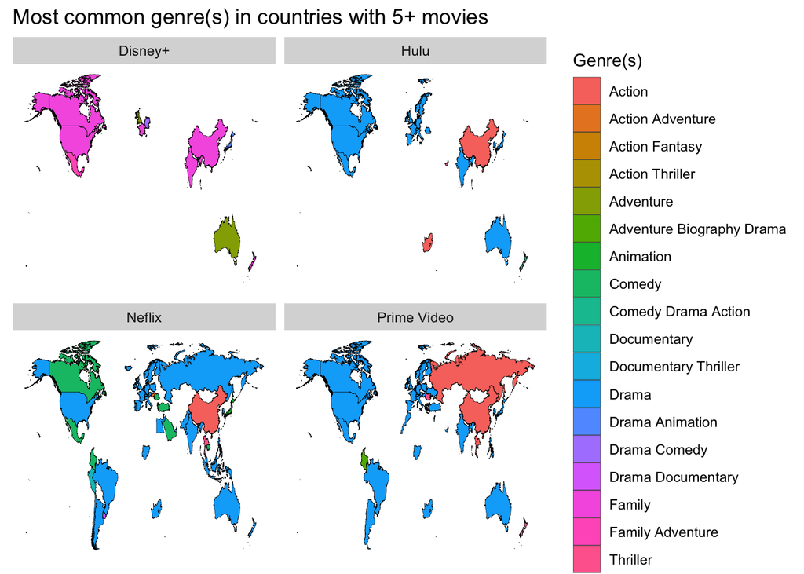

```r
map <- world_movie %>% ggplot(aes(x = long, y = lat, group = group, fill = genre)) +
   geom_polygon(color = "black", size = 0.1) +
  facet_wrap(~ platform, ncol = 2) +
   theme(panel.grid.major = element_blank(),
         panel.background = element_blank(),
         axis.title = element_blank(),
         axis.text = element_blank(),
         axis.ticks = element_blank()) +
  ggtitle("Most common genre(s) in countries with 5+ movies") +
  labs(fill = "Genre(s)"); map
```